# Sample size justification

Steve Simon

## Who am I?

Steve Simon

- PhD Statistics, 1982, U Iowa
- Teach in Biomedical and Health Informatics
  - Previous jobs at CMH, CDC
- Part-time independent statistical consultant (P.Mean Consulting)
- Married to a Pediatric Cardiologist (retired)
- Run 5K and 4 mile races

## Outline of this talk

- Pop quiz
- Sample size justification is an economic justification
- Definitions
- Specifying a research hypothesis
- Identifying the variation in your outcome
- Determining the minimum clinically important difference
- Repeat of pop quiz

## Pop quiz, question #1

- A good sample size will produce
  - 1. Large values for both alpha and beta.
  - 2. A large value for alpha and a small value for beta.
  - 3. A small value for alpha and a large value for beta.
  - 4. Small values for both alpha and beta.
  - 5. I’m awfully glad I’m a Beta, because I don’t work so hard.
  - 6. I don’t know the answer.

## Pop quiz, question #2

- One of the three things you need to calculate an appropriate sample size is
  - 1. A confidence interval for your outcome variable
  - 2. A range for your outcome variable
  - 3. A standard deviation for your outcome variable.
  - 4. A standard error for your outcome variable.
  - 5. Any of these is fine.
  - 6. I don’t know the answer.

## Pop quiz, question #3

- The minimum clinically important difference is determined by
  - 1. Finding a balance between the benefits and the harms of a new drug.
  - 2. Finding a balance between the cost of sampling an additional patient and the incremental reduction in uncertainty.
  - 3. Finding a balance between Type I and Type II error rates.
  - 4. Finding a balance between your work and your family.
  - 5. More than one answer above is correct.
  - 6. I don’t know the answer.

## A sad tale of research

- A researcher is finishing up a six year, ten million dollar NIH grant and writes up in the final report
  - “This is a new and innovative surgical procedure and we are 95% confident that the cure rate is somewhere between 3% and 98%.”

## A second sad tale of research

- Confidence interval for an odds ratio: 0.82 to 3.14.
  - Interpret this interval

## Sample size justification is an economic justification

- Larger samples cost more money
  - but provide more precision
  - diminishing returns
- Balance cost versus precision

## Real example of economic tradeoff

- Overbilling problem
  - Need to estimate excess to process a refund
  - Audit of all records too expensive
  - 2,000 records, $100 per record
- Sample how many records?

## Solution

- Estimate 95% confidence interval for excess
  - Pay the upper limit
- Balance size of upper limit versus cost

## Solution displayed graphically

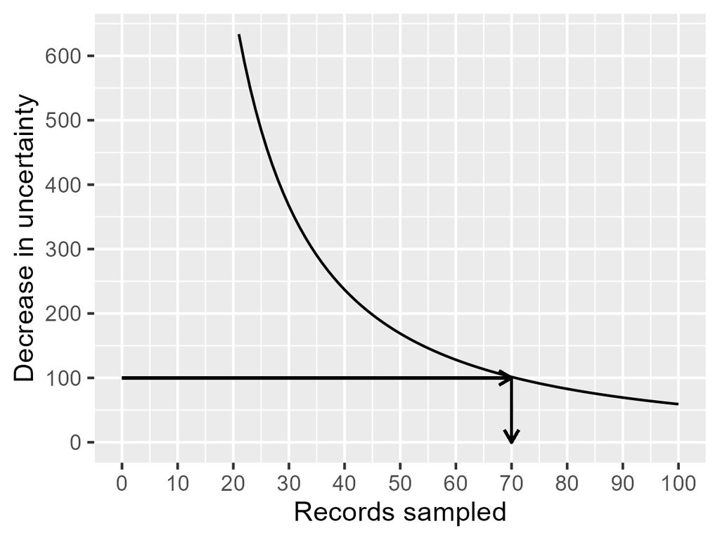

Figure 1. Decrease in uncertainty versus sample size

## Ethical concerns about an inadequate sample size

- People volunteer for research studies for three reasons:
  - To earn some money,
  - To find out more about the research process, or
  - To help other people.
- An inadequate sample size invalidates third reason

## Ethical concerns about an excessive sample size

- Features of some (not all) clinical trials
  - Small/moderate amount of pain
  - Endure a risky procedure, or
  - Forgoing an appropriate medical treatment
- In these cases, too large a sample is problematic.

## Break #1

- What have you learned?
  - Pop quiz
  - Sample size as an economic justification
- What is coming next?
  - Definitions

## Definition: population

- Usually defined by
  - Demography,
  - Geography,
  - Occupation,
  - Time,
  - Care requirements,
  - Diagnosis
  - or some combination

## Example of a population

All infants born in the state of Missouri during the 1995 calendar year who have one or more visits to the Emergency room during their first year of life.

## Definitions: sample

- Subset of a population.
  - Random sample:
    - every item in the population has the same probability of being in the sample.
  - Biased sample:
    - some items in the population have a decreased probability of being in the sample.

## Definitions: parameter and statistic

- Parameter: number computed from a population
  - $\mu$, $\sigma$, $\pi$, $\rho$
- Statistic: number computed from a sample
  - $\bar{X}$, $S$, $p$ or $\hat{p}$, $r$.

## Putting it all togther

Statistics is the use of one or more **statistics** computed from a **sample** to make an inference about one or more **parameters** from a **population**.

## Definition: null hypothesis

- The null hypothesis is, by tradition, a hypothesis that represents
  - no change,
  - no difference, or
  - the status quo
- The null hypothesis is expressed using parameters (Greek)
  - $H_0 \ \mu=100$
  - $H_0 \ \pi_1=\pi_2$
  - $H_0 \ \rho=0$

## Definition: alternative hypothesis

- The alternative hypothesis is complementary to the null hypothesis
  - $H_1 \ \mu \ne 100$
  - $H_1 \ \pi_1 \ne \pi_2$
  - $H_1 \ \rho \ne 0$
- Note: no discussion of
  - one-sided hypotheses,
  - equivalence hypotheses,
  - non-inferiority hypotheses

## Definitions: Type I error

- A Type I error is
  - rejecting the $H_0$ when $H_0$ is true.
  - It is also known as a false positive.
- Example involving drug approval:
  - a Type I error is allowing an ineffective drug onto the market.

## Definitions: Type II error

- A Type II error is
  - accepting $H_0$ when $H_0$ is false.
  - It is also known as a false negative
- Example involving drug approval:
  - a Type II error is keeping an effective drug off of the market.

## Definition: Power function

- Probablity of rejecting the null hypothesis for various values in the alternative hypothesis
- Power is a function of
  - Parameter(s)
  - Alpha
  - Sample size
- Power = 1 - $\beta$

## Example of a power function

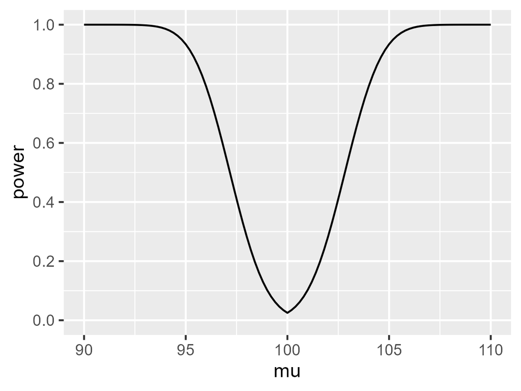

Figure 2. Relationship between power and hypothesized mean

## Power as a function of sample size

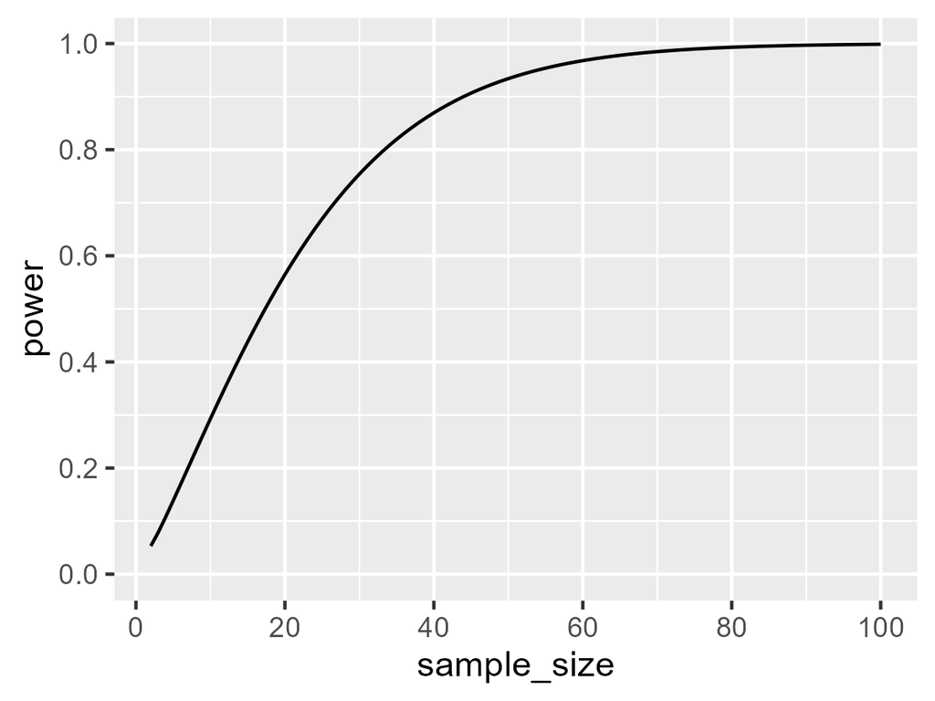

Figure 3. Relationship between power and sample size

## Sample size justification

In a nutshell, choose a sample size large enough

- to insure that the chances of making a Type I or a Type II error are both small. or
- (equivalently) to insure that alpha is small and power is large. or
- to produce a reasonably narrow confidence interval.

## Three things that you need to justify your sample size.

- Research hypothesis
- Standard deviation of your outcome measure
- Minimum clinically important difference

## Break #2

- What have you learned?
  - Definitions
- What is coming next?
  - Specifying a research hypothesis
  - Identifying the variation in your outcome

## Specifying the research hypothesis

- Use PICO
  - P: patient population
  - I: intervention (sometimes E: exposure)
  - C: comparison or control group
  - O: outcome

## Finding the standard deviation

- Run a pilot study
- From previous research
  - Maybe already sitting in your draft bibliography
  - Reasonably comaparable
  - Same outcome measure
  - Similar study population

## Inferring a standard deviation from other measures of variation

- If the paper does not have a standard deviation, look for
  - a standard error,
  - a coefficient of variation,
  - a confidence intervals, or
  - a range ($S \approx RANGE/4$)
- For a binary outcome
  - No standard deviation needed
  - Find the baseline or control proportion instead

## Break #3

- What have you learned?
  - Specifying a research hypothesis
  - Identifying the variation in your outcome
- What is coming next?
  - Determining the minimum clinically important difference
  - Repeat of pop quiz

## Determining the minimum clinically important difference

- Requires clinical judgement
  - Some differences are clinically trivial
  - Large enough to change professional opinion
  - Large enough so that patients notice
- Example: Pain score
  - Measured on visual analog scale (0-100)
  - Patients only feel better with a shift of 15 points

## Cost-benefit tradeoff

- For a binary outcome
  - X = the cost of the treatment
  - kX = benefit of the cure
  - MCD = 1/k
- Examples
  - Aromatherapy
  - Gerson therapy (coffee enemas)

## Practical example of sample size justification

- Comparison of two skin barriers for burn patients
  - Pain
  - Healing time
  - Cost

## Sample size justification using pain

- Oucher scale
  - S = 1.5
  - MCD = 1

$$n = \frac{(\sigma_1^2+\sigma_2^2)(z_{1-\alpha/2}+z_{1-\beta})}{MCD^2}$$

n=35.3, round up to n=36 per group.

## Sample size calculation using R

```
> power.t.test(delta=1, sd=1.5, sig.level=0.05, power=0.80, type="two.sample")

     Two-sample t test power calculation

              n = 36.3058
          delta = 1
             sd = 1.5
      sig.level = 0.05
          power = 0.8
    alternative = two.sided

NOTE: n is number in *each* group
```

## Power calculation using PiFace, 1

[figure not shown]

Figure 4. Excerpt from PiFace website

## Power calculation using PiFace, 2

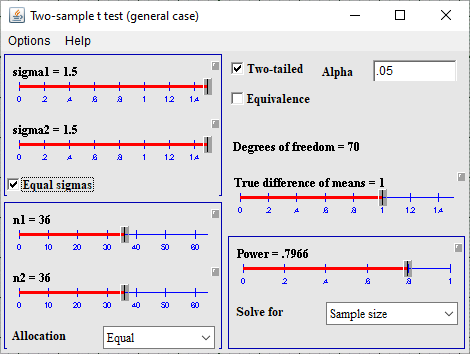

Figure 5. Screenshot of PiFace program

## Pop quiz, question #1

- A good sample size will produce
  - 1. Large values for both alpha and beta.
  - 2. A large value for alpha and a small value for beta.
  - 3. A small value for alpha and a large value for beta.
  - 4. Small values for both alpha and beta.
  - 5. I’m awfully glad I’m a Beta, because I don’t work so hard.
  - 6. I don’t know the answer.

## Pop quiz, question #2

- One of the three things you need to calculate an appropriate sample size is
  - 1. A confidence interval for your outcome variable
  - 2. A range for your outcome variable
  - 3. A standard deviation for your outcome variable.
  - 4. A standard error for your outcome variable.
  - 5. Any of these is fine.
  - 6. I don’t know the answer.

## Pop quiz, question #3

- The minimum clinically important difference is determined by
  - 1. Finding a balance between the benefits and the harms of a new drug.
  - 2. Finding a balance between the cost of sampling an additional patient and the incremental reduction in uncertainty.
  - 3. Finding a balance between Type I and Type II error rates.
  - 4. Finding a balance between your work and your family.
  - 5. More than one answer above is correct.
  - 6. I don’t know the answer.

## Summary

- Pop quiz
- Sample size justification is an economic justification
- Definitions
- Specifying a research hypothesis
- Identifying the variation in your outcome
- Determining the minimum clinically important difference
- Repeat of pop quiz